# only_load

```python
import pandas as pd
import matplotlib.pyplot as plt
import seaborn as sns
import re
import nltk
import langdetect
import spacy
from sklearn import feature_extraction, manifold
from sklearn.feature_extraction.text import CountVectorizer
```

```python
df=pd.read_csv('1.csv')
df.head()
```

|  | Unnamed: 0 | category | headline | authors | link | short_description | date |
| --- | --- | --- | --- | --- | --- | --- | --- |
| 0 | 0 | TRAVEL | Craft Beers and Craft Skis: An Inspired Pairin... | Liftopia, Contributor\nLargest online and mobi... | https://www.huffingtonpost.com/entry/craft-bee... | The Beer: Oktoberfest-Great Lakes Brewing Co T... | 2014-01-27 |
| 1 | 1 | TRAVEL | Greece's Breathtaking Vikos Gorge, The World's... | Mike Arkus, ContributorJournalist | https://www.huffingtonpost.com/entry/greeces-b... | NaN | 2016-05-08 |
| 2 | 2 | TRAVEL | Ready To Go To Westeros? | Lisa_Miller | https://www.huffingtonpost.com/entry/game-of-t... | NaN | 2014-06-20 |
| 3 | 3 | HOME & LIVING | 8 Plants That Snobs Love To Hate -- And You'll... | NaN | https://www.huffingtonpost.comhttp://www.houzz... | Some time ago a mother of the bride was lament... | 2013-08-11 |
| 4 | 4 | HOME & LIVING | 3 Myths About Buying Your First Home | Eric Roberge, CFP, Contributor\nI help profess... | https://www.huffingtonpost.com/entry/3-myths-a... | A purchase that looks like a home run from the... | 2014-02-06 |

```python
## Rename Columns
df = df.rename(columns={"category":"y", "headline":"text"})
```

```python
#  Check the blank value
df.isnull().sum()
```

```
Unnamed: 0              0
y                      20
text                   19
authors              1180
link                   23
short_description     316
date                   12
dtype: int64
```

```python
df.dropna(inplace=True)
```

```python
#  Check the blank value
df.isnull().sum()
```

```
Unnamed: 0           0
y                    0
text                 0
authors              0
link                 0
short_description    0
date                 0
dtype: int64
```

# Task 1. Data understanding

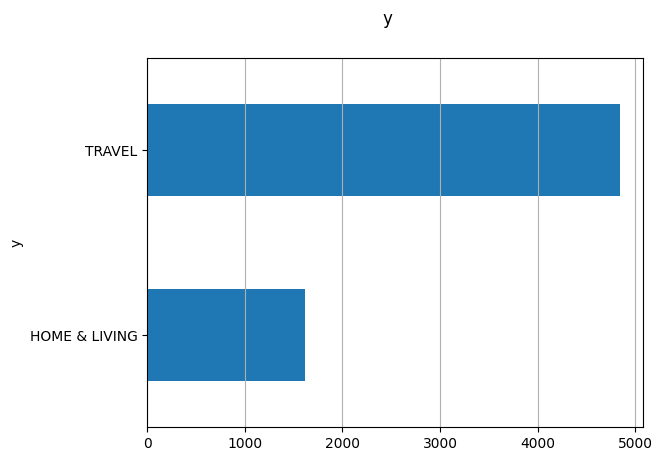

```python
#Bar chart showing label frequencies to study target variable distribution
x = "y"
fig, ax = plt.subplots()
fig.suptitle(x, fontsize=12)
df[x].reset_index().groupby(x).count().sort_values(by=
       "index").plot(kind="barh", legend=False,
        ax=ax).grid(axis='x')
plt.show()
```

### It is obvious that the number of travel variables is greater than home&living

```python
df['lang'] = df["text"].apply(lambda x: langdetect.detect(x) if
                                 x.strip() != "" else "")
df.head()
```

|  | Unnamed: 0 | y | text | authors | link | short_description | date | lang |
| --- | --- | --- | --- | --- | --- | --- | --- | --- |
| 0 | 0 | TRAVEL | Craft Beers and Craft Skis: An Inspired Pairin... | Liftopia, Contributor\nLargest online and mobi... | https://www.huffingtonpost.com/entry/craft-bee... | The Beer: Oktoberfest-Great Lakes Brewing Co T... | 2014-01-27 | en |
| 4 | 4 | HOME & LIVING | 3 Myths About Buying Your First Home | Eric Roberge, CFP, Contributor\nI help profess... | https://www.huffingtonpost.com/entry/3-myths-a... | A purchase that looks like a home run from the... | 2014-02-06 | en |
| 6 | 6 | TRAVEL | Everything It Will Take To Get Faster Wi-Fi On... | The Atlantic, ContributorExploring the America... | https://www.huffingtonpost.com/entry/everythin... | Yes, it will get better. | 2017-07-13 | en |
| 7 | 7 | HOME & LIVING | Canadian Penny Floor Is An Unusual Tribute To ... | Michelle Manetti | https://www.huffingtonpost.com/entry/canadian-... | It's not the first time we've seen the idea, b... | 2013-02-05 | en |
| 8 | 8 | TRAVEL | Travel Woes: The Airline Edition | Millie Kerr, Contributor\nFreelance Writer, mi... | https://www.huffingtonpost.com/entry/travel-wo... | Are bags lost that often? Is travel actually m... | 2012-04-06 | en |

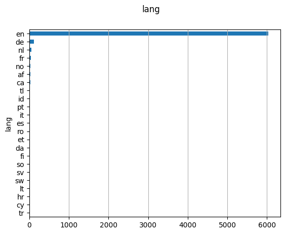

```python
x = "lang"
fig, ax = plt.subplots()
fig.suptitle(x, fontsize=12)
df[x].reset_index().groupby(x).count().sort_values(by=
       "index").plot(kind="barh", legend=False,
        ax=ax).grid(axis='x')
plt.show()
```

### It is clear that English is the primary language, so we filter the dataset in English

```python
df = df[df["lang"]=="en"]
```

## Text pre-processing

```python
nltk.download('wordnet')

def clean_text(text):
    # Clean the text (convert to lowercase, remove punctuation and characters, then strip)
    text = re.sub(r'[^\w\s]', '', str(text).lower().strip())
    return text

def remove_stopwords(lst_text, lst_stopwords):
    # Remove stopwords
    return [word for word in lst_text if word not in lst_stopwords]

def stem_text(lst_text, flg_stemm):
    # Perform stemming
    if flg_stemm:
        ps = nltk.stem.porter.PorterStemmer()
        return [ps.stem(word) for word in lst_text]
    return lst_text

def lemmatize_text(lst_text, flg_lemm):
    # Perform lemmatization
    if flg_lemm:
        lem = nltk.stem.wordnet.WordNetLemmatizer()
        return [lem.lemmatize(word) for word in lst_text]
    return lst_text

def utils_preprocess_text(text, flg_stemm=False, flg_lemm=True, lst_stopwords=None):
    # Clean the text
    text = clean_text(text)

    # Tokenize the text
    lst_text = text.split()

    # Remove stopwords
    if lst_stopwords is not None:
        lst_text = remove_stopwords(lst_text, lst_stopwords)

    # Stem the text
    lst_text = stem_text(lst_text, flg_stemm)

    # Lemmatize the text
    lst_text = lemmatize_text(lst_text, flg_lemm)

    # Convert the list back to a string
    text = " ".join(lst_text)
    return text
```

```python
lst_stopwords = nltk.corpus.stopwords.words("english")
lst_stopwords
```

[output not shown]

[output cut: 124 more lines]

```
 "mustn't",
 'needn',
 "needn't",
 'shan',
 "shan't",
 'shouldn',
 "shouldn't",
 'wasn',
 "wasn't",
 'weren',
 "weren't",
 'won',
 "won't",
 'wouldn',
 "wouldn't"]
```

```python
df["text_clean"] = df["text"].apply(lambda x: utils_preprocess_text(x, False, True, lst_stopwords))
df
```

|  | Unnamed: 0 | y | text | authors | link | short_description | date | lang | text_clean |
| --- | --- | --- | --- | --- | --- | --- | --- | --- | --- |
| 0 | 0 | TRAVEL | Craft Beers and Craft Skis: An Inspired Pairin... | Liftopia, Contributor\nLargest online and mobi... | https://www.huffingtonpost.com/entry/craft-bee... | The Beer: Oktoberfest-Great Lakes Brewing Co T... | 2014-01-27 | en | craft beer craft ski inspired pairing year bes... |
| 4 | 4 | HOME & LIVING | 3 Myths About Buying Your First Home | Eric Roberge, CFP, Contributor\nI help profess... | https://www.huffingtonpost.com/entry/3-myths-a... | A purchase that looks like a home run from the... | 2014-02-06 | en | 3 myth buying first home |
| 6 | 6 | TRAVEL | Everything It Will Take To Get Faster Wi-Fi On... | The Atlantic, ContributorExploring the America... | https://www.huffingtonpost.com/entry/everythin... | Yes, it will get better. | 2017-07-13 | en | everything take get faster wifi plane |
| 7 | 7 | HOME & LIVING | Canadian Penny Floor Is An Unusual Tribute To ... | Michelle Manetti | https://www.huffingtonpost.com/entry/canadian-... | It's not the first time we've seen the idea, b... | 2013-02-05 | en | canadian penny floor unusual tribute discontin... |
| 8 | 8 | TRAVEL | Travel Woes: The Airline Edition | Millie Kerr, Contributor\nFreelance Writer, mi... | https://www.huffingtonpost.com/entry/travel-wo... | Are bags lost that often? Is travel actually m... | 2012-04-06 | en | travel woe airline edition |
| ... | ... | ... | ... | ... | ... | ... | ... | ... | ... |
| 7991 | 7991 | TRAVEL | Memorial Day Driving Advice You Can Actually U... | Kari Astrid Haugeto, Contributor\nEntrepreneur... | https://www.huffingtonpost.com/entry/memorial-... | What's the best way to survive your the trip? | 2013-05-23 | en | memorial day driving advice actually use serio... |
| 7992 | 7992 | TRAVEL | The Best Destinations For Cheap Spring Travel | Conde Nast Traveler, Contributor\nConde Nast T... | https://www.huffingtonpost.com/entry/best-dest... | Last-minute airfare is always so expensive. | 2013-04-09 | en | best destination cheap spring travel |
| 7995 | 7995 | TRAVEL | Sumba, Indonesia: Lose Yourself In A Different... | Emi Boscamp | https://www.huffingtonpost.com/entry/sumba-ind... | If you need to get away -- far, far away -- to... | 2013-08-09 | en | sumba indonesia lose different world photo |
| 7998 | 7998 | TRAVEL | 3 Rules for Studying Abroad in Europe This Fall | Andy Steves, ContributorFounder & Chief Backpa... | https://www.huffingtonpost.com/entry/3-rules-f... | The weather's great and the pool is warm, yet ... | 2014-07-17 | en | 3 rule studying abroad europe fall |
| 7999 | 7999 | TRAVEL | Paddling The Erie Canal, 15 Miles Or More A Da... | Richard Harpham, Contributor\nMember of the Ne... | https://www.huffingtonpost.com/entry/paddling-... | The plan is to kayak along the Erie Canal to A... | 2012-05-16 | en | paddling erie canal 15 mile day photo |

6035 rows × 9 columns

```python
nltk.download('punkt')
```

```
True
```

## Analysis of commonly used terms

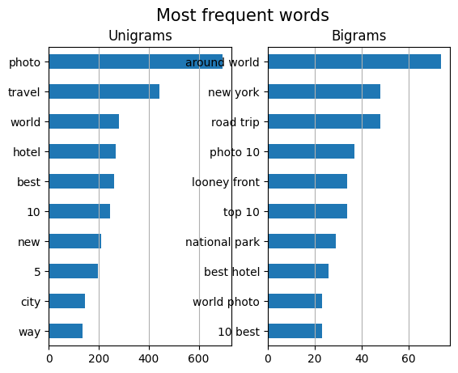

```python
y = "TRAVEL"
top=10
corpus = df[df["y"]==y]["text_clean"]
lst_tokens = nltk.tokenize.word_tokenize(corpus.str.cat(sep=" "))
fig, ax = plt.subplots(nrows=1, ncols=2)
fig.suptitle("Most frequent words", fontsize=15)

## unigrams
dic_words_freq = nltk.FreqDist(lst_tokens)
dtf_uni = pd.DataFrame(dic_words_freq.most_common(),
                       columns=["Word","Freq"])
dtf_uni.set_index("Word").iloc[:top,:].sort_values(by="Freq").plot(
                  kind="barh", title="Unigrams", ax=ax[0],
                  legend=False).grid(axis='x')
ax[0].set(ylabel=None)

## bigrams
dic_words_freq = nltk.FreqDist(nltk.ngrams(lst_tokens, 2))
dtf_bi = pd.DataFrame(dic_words_freq.most_common(),
                      columns=["Word","Freq"])
dtf_bi["Word"] = dtf_bi["Word"].apply(lambda x: " ".join(
                   string for string in x) )
dtf_bi.set_index("Word").iloc[:top,:].sort_values(by="Freq").plot(
                  kind="barh", title="Bigrams", ax=ax[1],
                  legend=False).grid(axis='x')
ax[1].set(ylabel=None)
plt.show()
```

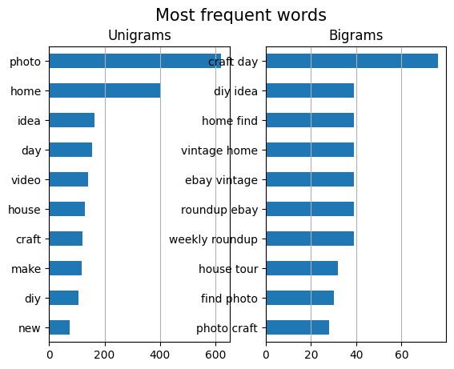

```python
y = "HOME & LIVING"
top=10
corpus = df[df["y"]==y]["text_clean"]
lst_tokens = nltk.tokenize.word_tokenize(corpus.str.cat(sep=" "))
fig, ax = plt.subplots(nrows=1, ncols=2)
fig.suptitle("Most frequent words", fontsize=15)

## unigrams
dic_words_freq = nltk.FreqDist(lst_tokens)
dtf_uni = pd.DataFrame(dic_words_freq.most_common(),
                       columns=["Word","Freq"])
dtf_uni.set_index("Word").iloc[:top,:].sort_values(by="Freq").plot(
                  kind="barh", title="Unigrams", ax=ax[0],
                  legend=False).grid(axis='x')
ax[0].set(ylabel=None)

## bigrams
dic_words_freq = nltk.FreqDist(nltk.ngrams(lst_tokens, 2))
dtf_bi = pd.DataFrame(dic_words_freq.most_common(),
                      columns=["Word","Freq"])
dtf_bi["Word"] = dtf_bi["Word"].apply(lambda x: " ".join(
                   string for string in x) )
dtf_bi.set_index("Word").iloc[:top,:].sort_values(by="Freq").plot(
                  kind="barh", title="Bigrams", ax=ax[1],
                  legend=False).grid(axis='x')
ax[1].set(ylabel=None)
plt.show()
```

## Analyse other features in the dataset and their relationship with the label

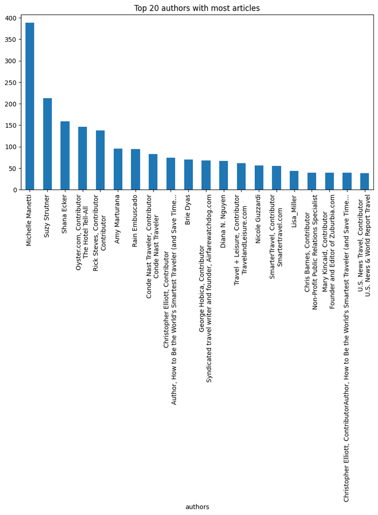

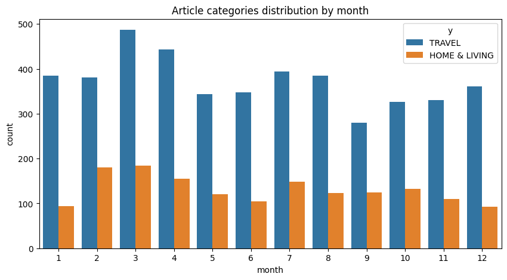

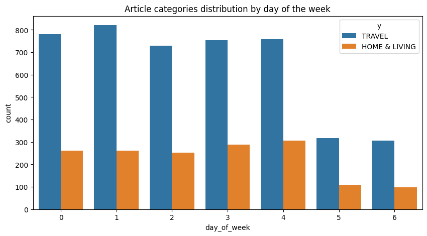

```python
# Replace empty values in the 'authors' field with 'Unknown'
df['authors'].fillna('Unknown', inplace=True)

# Calculate the number of articles for each author and plot a bar chart
author_counts = df['authors'].value_counts()
plt.figure(figsize=(10,5))
author_counts[:20].plot(kind='bar')
plt.title('Top 20 authors with most articles')
plt.show()

# Convert the 'date' field to datetime format and extract the month and day of the week
df['date'] = pd.to_datetime(df['date'])
df['month'] = df['date'].dt.month
df['day_of_week'] = df['date'].dt.dayofweek

# Plot the relationship between month and article categories
plt.figure(figsize=(10,5))
sns.countplot(data=df, x='month', hue='y')
plt.title('Article categories distribution by month')
plt.show()

# Plot the relationship between day of the week and article categories
plt.figure(figsize=(10,5))
sns.countplot(data=df, x='day_of_week', hue='y')
plt.title('Article categories distribution by day of the week')
plt.show()
```

## Length Analysis

```python
df['sentence_count'] = df["text"].apply(lambda x: len(str(x).split(".")))
df['word_count'] = df["text"].apply(lambda x: len(str(x).split(" ")))
df['avg_sentence_lenght'] = df['word_count'] / df['sentence_count']
df['word_count']
```

```
0       15
4        7
6       10
7       12
8        5
        ..
7991    11
7992     7
7995     9
7998     9
7999    11
Name: word_count, Length: 6035, dtype: int64
```

```python
df['avg_sentence_lenght']
```

```
0       15.0
4        7.0
6       10.0
7       12.0
8        5.0
        ...
7991    11.0
7992     7.0
7995     9.0
7998     9.0
7999    11.0
Name: avg_sentence_lenght, Length: 6035, dtype: float64
```

```python
#  Check the blank value
df.isnull().sum()
```

```
Unnamed: 0             0
y                      0
text                   0
authors                0
link                   0
short_description      0
date                   0
lang                   0
text_clean             0
month                  0
day_of_week            0
sentence_count         0
word_count             0
avg_sentence_lenght    0
dtype: int64
```

```python
df.dropna(inplace=True)
```

```python
df.head()
```

|  | Unnamed: 0 | y | text | authors | link | short_description | date | lang | text_clean | month | day_of_week | sentence_count | word_count | avg_sentence_lenght |
| --- | --- | --- | --- | --- | --- | --- | --- | --- | --- | --- | --- | --- | --- | --- |
| 0 | 0 | TRAVEL | Craft Beers and Craft Skis: An Inspired Pairin... | Liftopia, Contributor\nLargest online and mobi... | https://www.huffingtonpost.com/entry/craft-bee... | The Beer: Oktoberfest-Great Lakes Brewing Co T... | 2014-01-27 | en | craft beer craft ski inspired pairing year bes... | 1 | 0 | 1 | 15 | 15.0 |
| 4 | 4 | HOME & LIVING | 3 Myths About Buying Your First Home | Eric Roberge, CFP, Contributor\nI help profess... | https://www.huffingtonpost.com/entry/3-myths-a... | A purchase that looks like a home run from the... | 2014-02-06 | en | 3 myth buying first home | 2 | 3 | 1 | 7 | 7.0 |
| 6 | 6 | TRAVEL | Everything It Will Take To Get Faster Wi-Fi On... | The Atlantic, ContributorExploring the America... | https://www.huffingtonpost.com/entry/everythin... | Yes, it will get better. | 2017-07-13 | en | everything take get faster wifi plane | 7 | 3 | 1 | 10 | 10.0 |
| 7 | 7 | HOME & LIVING | Canadian Penny Floor Is An Unusual Tribute To ... | Michelle Manetti | https://www.huffingtonpost.com/entry/canadian-... | It's not the first time we've seen the idea, b... | 2013-02-05 | en | canadian penny floor unusual tribute discontin... | 2 | 1 | 1 | 12 | 12.0 |
| 8 | 8 | TRAVEL | Travel Woes: The Airline Edition | Millie Kerr, Contributor\nFreelance Writer, mi... | https://www.huffingtonpost.com/entry/travel-wo... | Are bags lost that often? Is travel actually m... | 2012-04-06 | en | travel woe airline edition | 4 | 4 | 1 | 5 | 5.0 |

# Data Preparation & Modelling

```python
from sklearn.feature_extraction.text import CountVectorizer, ENGLISH_STOP_WORDS, TfidfVectorizer
from sklearn.preprocessing import LabelEncoder
from sklearn.naive_bayes import MultinomialNB
from sklearn.model_selection import train_test_split, cross_val_score, GridSearchCV
from sklearn.metrics import confusion_matrix, classification_report, cohen_kappa_score
import tensorflow as tf
from tensorflow import keras
import numpy as np
from tensorflow.keras.preprocessing.text import Tokenizer
from tensorflow.keras.preprocessing.sequence import pad_sequences
from sklearn.model_selection import train_test_split
from sklearn.metrics import classification_report, confusion_matrix
from tensorflow.keras.layers import Embedding
from tensorflow.keras.layers import LSTM, GRU, Dense, Embedding, Dropout
from tensorflow.keras.preprocessing import text, sequence
from tensorflow.keras.models import Sequential
from sklearn.model_selection import train_test_split
import pandas as pd
import numpy as np
import string
from tensorflow.keras import models
from tensorflow.keras import layers
from tensorflow.keras import losses
from tensorflow.keras import metrics
from tensorflow.keras import optimizers
from tensorflow.keras.callbacks import EarlyStopping
from tensorflow.keras.preprocessing.sequence import pad_sequences
from tensorflow.keras.preprocessing.text import Tokenizer
from sklearn.model_selection import train_test_split
from nltk.tokenize import word_tokenize
from nltk.corpus import stopwords
import time
from sklearn.manifold import TSNE
from tensorflow.keras.models import Model,Sequential
from tensorflow.keras.layers import Embedding,Dense,LSTM,Dropout,GlobalAveragePooling1D,Bidirectional
from tensorflow.keras.preprocessing.text import Tokenizer
from tensorflow.keras.optimizers import Adam
from tensorflow.keras.preprocessing.sequence import pad_sequences
from tensorflow.keras.callbacks import ModelCheckpoint,EarlyStopping
from tensorflow.keras.utils import plot_model
```

```python
# Reading training data from .CSV file
train_df = pd.read_csv('train.csv')

# Extract features and labels
X_train = train_df['text_clean'].values
y_train = train_df['y'].values
```

```python
# Read Testing data From .CSV file
test_df = pd.read_csv('test.csv')

# Extract features and labels
X_test = test_df['text_clean'].values
y_test = test_df['y'].values
```

```python
# Read Validation data from .CSV
val_df = pd.read_csv('valid.csv')

# Extract labels and features
X_val = val_df['text_clean'].values
y_val = val_df['y'].values
```

```python
vocab_size =20000
max_length = 150
trunc_type='post'
padding_type='post'
oov_tok = "<OOV>"
```

```python
tokenizer = tf.keras.preprocessing.text.Tokenizer(num_words=vocab_size, oov_token=oov_tok)
tokenizer.fit_on_texts(X_train)

word_index = tokenizer.word_index

# Convert training data to sequences
X_train = tokenizer.texts_to_sequences(X_train)
X_train = pad_sequences(X_train, maxlen=max_length, padding=padding_type, truncating=trunc_type)

# Convert training labels to one-hot encoded vectors
y_train = np.asarray(y_train)
y_train = pd.get_dummies(y_train)

# Convert validation data to sequences
X_val = tokenizer.texts_to_sequences(X_val)
X_val = pad_sequences(X_val, maxlen=max_length, padding=padding_type, truncating=trunc_type)

# Convert validation labels to one-hot encoded vectors
y_val = np.asarray(y_val)
y_val = pd.get_dummies(y_val)

# Convert data and labels to arrays
train_set = np.array(X_train)
val_set = np.array(X_val)
train_label = np.array(y_train)
val_label = np.array(y_val)
# test_set = np.array(X_test)
# test_label = np.array(y_test)

# Convert test labels to one-hot encoded vectors and extract the class indices
y_test = pd.get_dummies(y_test)
y_test = np.asarray(y_test)
y_test = np.argmax(y_test, axis=1)

# Print the shapes of the training and validation data and labels
print('Train set shape:', train_set.shape)
print('Train label shape:', train_label.shape)
print('Validation set shape:', val_set.shape)
print('Validation label shape:', val_label.shape)
```

```
Train set shape: (4833, 150)
Train label shape: (4833, 2)
Validation set shape: (605, 150)
Validation label shape: (605, 2)
```

## Naive Bayes classifier

```python
from sklearn.naive_bayes import MultinomialNB
from sklearn.metrics import accuracy_score

# # Create a Naive Bayes classifier
# nb_classifier = MultinomialNB()

# # Convert the two-dimensional label array to a one-dimensional array
train_label_1 = np.argmax(train_label, axis=1)
val_label_1 = np.argmax(val_label, axis=1)

# # Train the model using the training set
# nb_classifier.fit(train_set, train_label_1)

# # Make predictions on the training set
# train_predictions = nb_classifier.predict(train_set)
# train_accuracy = accuracy_score(train_label_1, train_predictions)
# print("Training Set Accuracy:", train_accuracy)

# # Make predictions on the validation set
# val_predictions = nb_classifier.predict(val_set)
# val_accuracy = accuracy_score(val_label_1, val_predictions)
# print("Validation Set Accuracy:", val_accuracy)
```

```python
# # Print all the parameters of the trained model
# print("Model Parameters:")
# print(nb_classifier.get_params())
```

```python
import joblib

# # Save the trained model
# joblib.dump(nb_classifier, 'naive_bayes_model.pkl')
```

## DecisionTree

```python
from sklearn.tree import DecisionTreeClassifier
from sklearn.metrics import accuracy_score

# # Create a Decision Tree classifier
# dt_classifier = DecisionTreeClassifier()

# # Train the model using the training set
# dt_classifier.fit(train_set, train_label_1)

# # Make predictions on the training set
# train_predictions = dt_classifier.predict(train_set)
# train_accuracy = accuracy_score(train_label_1, train_predictions)
# print("Training Set Accuracy:", train_accuracy)

# # Make predictions on the validation set
# val_predictions = dt_classifier.predict(val_set)
# val_accuracy = accuracy_score(val_label_1, val_predictions)
# print("Validation Set Accuracy:", val_accuracy)
```

```python
# # Print all the parameters of the trained model
# print("Model Parameters:")
# print(dt_classifier.get_params())
```

```python
# joblib.dump(dt_classifier, 'dt_model.pkl')
```

```python
path_to_glove_file =  'glove.6B.100d.txt/glove.6B.100d.txt'
```

```python
num_tokens = len(tokenizer.word_index.items()) + 2
embedding_dim = 100
hits = 0
misses = 0

# Create an empty dictionary to store word vectors
embeddings_index = {}

# Open the GloVe file and read line by line
with open(path_to_glove_file, encoding='utf-8') as f:
    for line in f:
        # Split each line into word and coefficients
        word, coefs = line.split(maxsplit=1)
        # Convert coefficients to a numpy array
        coefs = np.fromstring(coefs, "f", sep=" ")
        # Store the word and its corresponding coefficients in the dictionary
        embeddings_index[word] = coefs

# Print the number of word vectors found in the GloVe file
print("Found %s word vectors." % len(embeddings_index))

# Create an embedding matrix with all zeros
embedding_matrix = np.zeros((num_tokens, embedding_dim))

# Iterate over each word in the tokenizer's word index
for word, i in tokenizer.word_index.items():
    # Get the corresponding embedding vector from the embeddings dictionary
    embedding_vector = embeddings_index.get(word)
    if embedding_vector is not None:
        # If an embedding vector is found, update the corresponding row in the embedding matrix
        embedding_matrix[i] = embedding_vector
        hits += 1
    else:
        # If an embedding vector is not found, keep the row as all zeros
        misses += 1

# Print the number of words converted to embeddings and the number of misses
print("Converted %d words (%d misses)" % (hits, misses))
```

```
Found 400000 word vectors.
Converted 6397 words (548 misses)
```

## end-to-end classifier using deep learning

```python
# early_stop = tf.keras.callbacks.EarlyStopping(monitor='val_loss', patience=3, min_delta=0.0001)

# tf.keras.backend.clear_session()
# embed_size = 100

# model = keras.models.Sequential([
#     # Embedding layer with pre-trained word embeddings
#     Embedding(num_tokens,
#               embedding_dim,
#               embeddings_initializer=keras.initializers.Constant(embedding_matrix),
#               mask_zero=True,
#               input_shape=[None],
#               trainable=False),
#     # Bidirectional LSTM layer
#     keras.layers.Bidirectional(keras.layers.LSTM(256, dropout=0.4)),
#     # Output Dense layer with softmax activation for binary classification
#     keras.layers.Dense(2, activation="softmax")
# ])

# # Print the model summary
# model.summary()
```

```python
# opt = keras.optimizers.Adam(learning_rate=0.001)
# model.compile(loss="categorical_crossentropy", optimizer=opt, metrics=["accuracy"])
# history = model.fit( train_set,train_label,
#                      batch_size = 32,
#                      steps_per_epoch=len(X_train) // 32,
#                      validation_data = (val_set , val_label),
#                      validation_steps = len(val_set)//32, epochs=20,
#                      callbacks=  early_stop )
```

```python
# model.save("deeplearning_model.h5")
```

## Evaluation

```python
#loading model
from tensorflow.keras.models import load_model
import pickle
dl_model=load_model("deeplearning_model.h5")
# Load the Naive Bayes model from the file
naive_bayes_model = joblib.load('naive_bayes_model.pkl')
#Load the Decision Tree model from the file
decision_tree_model = joblib.load('dt_model.pkl')
```

```python
dl_model.summary()
```

```
Model: "sequential"
_________________________________________________________________
 Layer (type)                Output Shape              Param #
=================================================================
 embedding (Embedding)       (None, None, 100)         694700

 bidirectional (Bidirectiona  (None, 512)              731136
 l)

 dense (Dense)               (None, 2)                 1026

=================================================================
Total params: 1,426,862
Trainable params: 732,162
Non-trainable params: 694,700
_________________________________________________________________
```

### I choose accuracy_score as the metric There are several reasons for this:Intuitiveness: Accuracy is an intuitive and easy to understand metric that indicates the percentage of samples correctly predicted by the model. People usually have an intuitive understanding of accuracy and are able to compare it to other metrics.Composite: Accuracy combines the predictive power of a model across all categories, and it takes into account the model's classification accuracy across the entire data set. This makes accuracy a commonly used performance metric, especially when the categories are of similar importance.Generality: Accuracy is applicable to many types of classification problems, whether dichotomous or multicategorical. This makes it a common evaluation metric that can be applied to a variety of domains and application scenarios.

### The larger the accuracy_score, the better

### Evaluate performance on validation and training sets

```python
# Make predictions on the training set
train_predictions = naive_bayes_model.predict(train_set)
train_accuracy = accuracy_score(train_label_1, train_predictions)
print("Training Set Accuracy:", train_accuracy)

# Make predictions on the validation set
val_predictions = naive_bayes_model.predict(val_set)
val_accuracy = accuracy_score(val_label_1, val_predictions)
print("Validation Set Accuracy:", val_accuracy)
```

```
Training Set Accuracy: 0.7051520794537555
Validation Set Accuracy: 0.7008264462809918
```

```python
# Make predictions on the training set using the decision tree model
train_predictions_dt = decision_tree_model.predict(train_set)
train_accuracy_dt = accuracy_score(train_label_1, train_predictions_dt)
print("Training Set Accuracy:", train_accuracy_dt)

# Make predictions on the validation set using the decision tree model
val_predictions_dt = decision_tree_model.predict(val_set)
val_accuracy_dt = accuracy_score(val_label_1, val_predictions_dt)
print("Validation Set Accuracy:", val_accuracy_dt)
```

```
Training Set Accuracy: 1.0
Validation Set Accuracy: 0.7057851239669422
```

```python
# Make predictions on the training set using the deep learning model
train_predictions_dl = dl_model.predict(train_set)
train_predictions_dl = np.argmax(train_predictions_dl, axis=1)
train_accuracy_dl = accuracy_score(np.argmax(train_label, axis=1), train_predictions_dl)
print("Training Set Accuracy:", train_accuracy_dl)

# Make predictions on the validation set using the deep learning model
val_predictions_dl = dl_model.predict(val_set)
val_predictions_dl = np.argmax(val_predictions_dl, axis=1)
val_accuracy_dl = accuracy_score(np.argmax(val_label, axis=1), val_predictions_dl)
print("Validation Set Accuracy:", val_accuracy_dl)
```

```
Training Set Accuracy: 0.9877922615352783
Validation Set Accuracy: 0.9338842975206612
```

### The training set generally outperforms the validation set，Model Performance Deep Learning Model > Decision Tree> naive_bayes

### 11 Finding the optimal parameters

```python
from sklearn.model_selection import GridSearchCV
from sklearn.naive_bayes import MultinomialNB
from sklearn.metrics import accuracy_score
import joblib

# Create a Naive Bayes classifier
nb_classifier1 = MultinomialNB()

# Define the parameter grid to search over
param_grid = {'alpha': [0.05,0.1, 0.5, 1.0],
              'fit_prior': [True, False],
              'class_prior': [None, [0.2, 0.8], [0.5, 0.5]]}

# Create the GridSearchCV object
grid_search = GridSearchCV(nb_classifier1, param_grid, cv=5)

# Fit the GridSearchCV object on the training set
grid_search.fit(train_set, train_label_1)

# Get the best parameter values and the corresponding model
best_params = grid_search.best_params_
best_model = grid_search.best_estimator_

# Save the optimized Naive Bayes model
joblib.dump(best_model, 'optimized_naive_bayes_model.pkl')

# Make predictions on the training set using the best model
train_predictions_opt_bayes = best_model.predict(train_set)
train_accuracy_opt_bayes = accuracy_score(train_label_1, train_predictions_opt_bayes)
print("Training Set Accuracy (optimized):", train_accuracy_opt_bayes)

# Make predictions on the validation set using the best model
val_predictions_opt_bayes = best_model.predict(val_set)
val_accuracy_opt_bayes = accuracy_score(val_label_1, val_predictions_opt_bayes)
print("Validation Set Accuracy (optimized):", val_accuracy_opt_bayes)
best_params
```

```
Training Set Accuracy (optimized): 0.7049451686323195
Validation Set Accuracy (optimized): 0.7008264462809918
```

```
{'alpha': 0.05, 'class_prior': [0.2, 0.8], 'fit_prior': True}
```

```python
# Create a Decision Tree classifier
dt_classifier = DecisionTreeClassifier()

# Define the parameter grid to search over
param_grid = {'criterion': ['gini', 'entropy'],
              'max_depth': [None, 5, 10],
              'min_samples_split': [2, 5, 10],
              'min_samples_leaf': [1, 2, 4]}

# Create the GridSearchCV object
grid_search = GridSearchCV(dt_classifier, param_grid, cv=5)

# Fit the GridSearchCV object on the training set
grid_search.fit(train_set, train_label_1)

# Get the best parameter values and the corresponding model
best_params = grid_search.best_params_
best_model = grid_search.best_estimator_

# Save the optimized Decision Tree model
joblib.dump(best_model, 'optimized_decision_tree_model.pkl')

# Make predictions on the training set using the best model
train_predictions_opt_dt = best_model.predict(train_set)
train_accuracy_opt_dt = accuracy_score(train_label_1, train_predictions_opt_dt)
print("Training Set Accuracy (optimized):", train_accuracy_opt_dt)

# Make predictions on the validation set using the best model
val_predictions_opt_dt = best_model.predict(val_set)
val_accuracy_opt_dt = accuracy_score(val_label_1, val_predictions_opt_dt)
print("Validation Set Accuracy (optimized):", val_accuracy_opt_dt)
```

```
Training Set Accuracy (optimized): 0.8636457686737017
Validation Set Accuracy (optimized): 0.7487603305785124
```

### Add an additional LSTM layer to the model

```python
# # Define early stopping callback
# early_stop = tf.keras.callbacks.EarlyStopping(monitor='val_loss', patience=3, min_delta=0.001)

# # Clear previous TensorFlow session
# tf.keras.backend.clear_session()

# # Define embedding size
# embed_size = 100

# # Create the optimized model
# model_opt = keras.models.Sequential([
#     # Embedding layer with pre-trained word embeddings
#     Embedding(num_tokens,
#               embedding_dim,
#               embeddings_initializer=keras.initializers.Constant(embedding_matrix),
#               mask_zero=True,
#               input_shape=[None],
#               trainable=False),
# # Bidirectional LSTM layers
#     keras.layers.Bidirectional(keras.layers.LSTM(256, dropout=0.4, return_sequences=True)),
#     keras.layers.Bidirectional(keras.layers.LSTM(128, dropout=0.3)),
#     keras.layers.Dense(2, activation="softmax")
# ])

# # Compile the model with the optimizer and loss function
# opt = keras.optimizers.Adam(learning_rate=0.001)
# model_opt.compile(loss="categorical_crossentropy", optimizer=opt, metrics=["accuracy"])

# # Print the summary of the optimized model
# model_opt.summary()
```

[output not shown]

```python
# history = model_opt.fit( train_set,train_label,
#                      batch_size = 32,
#                      steps_per_epoch=len(X_train) // 32,
#                      validation_data = (val_set , val_label),
#                      validation_steps = len(val_set)//32, epochs=20,
#                      callbacks=  early_stop )
```

```python
# model_opt.save("deeplearning_model_opt.h5")
model_opt=load_model("deeplearning_model_opt.h5")
```

```python
# Make predictions on the training set using the deep learning model
train_predictions_dl_opt = model_opt.predict(train_set)
train_predictions_dl_opt = np.argmax(train_predictions_dl_opt, axis=1)
train_accuracy_dl_opt = accuracy_score(np.argmax(train_label, axis=1), train_predictions_dl_opt)
print("Training Set Accuracy:", train_accuracy_dl_opt)
```

```
Training Set Accuracy: 0.9776536312849162
```

```python
# Make predictions on the validation set using the deep learning model
val_predictions_dl_opt = model_opt.predict(val_set)
val_predictions_dl_opt = np.argmax(val_predictions_dl_opt, axis=1)
val_accuracy_dl_opt = accuracy_score(np.argmax(val_label, axis=1), val_predictions_dl_opt)
print("Validation Set Accuracy:", val_accuracy_dl_opt)
```

```
Validation Set Accuracy: 0.9289256198347108
```

### It can be seen that the classification accuracy of the best model among the three models, i.e., the deep learning model's Accuracy rate of over 90%, which can accomplish the task very well.

### Cross-validation

```python
# Load the optimized Naive Bayes model
optimized_naive_bayes_model = joblib.load('optimized_naive_bayes_model.pkl')
# Combine the training and validation sets
combined_train_set = np.concatenate((train_set, val_set), axis=0)
combined_train_label = np.concatenate((train_label_1, val_label_1), axis=0)
# Perform cross-validation on the combined dataset
scores = cross_val_score(optimized_naive_bayes_model, combined_train_set, combined_train_label, cv=5, scoring='accuracy')

# Print the cross-validation scores
print("Cross-Validation Scores:", scores)
print("Average Accuracy:", scores.mean())
```

```
Cross-Validation Scores: [0.71599265 0.69485294 0.71691176 0.68721251 0.69641214]
Average Accuracy: 0.7022764015909951
```

```python
# Load the optimized Naive Bayes model
optimized_decision_tree_model = joblib.load('optimized_decision_tree_model.pkl')
# Perform cross-validation on the combined dataset
scores_dt = cross_val_score(optimized_decision_tree_model, combined_train_set, combined_train_label, cv=5, scoring='accuracy')

# Print the cross-validation scores
print("Cross-Validation Scores:", scores_dt)
print("Average Accuracy:", scores_dt.mean())
```

```
Cross-Validation Scores: [0.78308824 0.77297794 0.78308824 0.78656854 0.72309108]
Average Accuracy: 0.7697628050760323
```

```python
dl_model_opt=load_model("deeplearning_model_opt.h5")
```

```python
merged_data = np.concatenate((train_set, val_set), axis=0)
merged_labels = np.concatenate((train_label, val_label), axis=0)
```

```python
from sklearn.model_selection import KFold

# Define the number of folds for cross-validation
n_splits = 5
kf = KFold(n_splits=n_splits, shuffle=True)

# Initialize a list to store the evaluation scores for each fold
accuracy_scores = []

# Train and evaluate the model for each fold
for train_index, test_index in kf.split(merged_data):
    # Get the training and testing data for the current fold
    X_train_fold, X_test_fold = merged_data[train_index], merged_data[test_index]
    y_train_fold, y_test_fold = merged_labels[train_index], merged_labels[test_index]

    # Use the pre-trained model to predict on the testing fold
    y_pred_fold = dl_model_opt.predict(X_test_fold)
    y_pred_fold = np.argmax(y_pred_fold, axis=1)

    # Calculate the accuracy score for the current fold
    accuracy_fold = accuracy_score(np.argmax(y_test_fold, axis=1), y_pred_fold)

    # Append the accuracy score to the list
    accuracy_scores.append(accuracy_fold)

# Print the evaluation scores for each fold
for i, score in enumerate(accuracy_scores):
    print("Fold", i+1, "Accuracy:", score)

# Calculate the average accuracy score
average_accuracy = np.mean(accuracy_scores)
print("Average Accuracy:", average_accuracy)
```

```
Fold 1 Accuracy: 0.9669117647058824
Fold 2 Accuracy: 0.9751838235294118
Fold 3 Accuracy: 0.96875
Fold 4 Accuracy: 0.968721251149954
Fold 5 Accuracy: 0.9816007359705612
Average Accuracy: 0.9722335150711618
```

### Select the best model

```python
best_model=load_model("deeplearning_model_opt.h5")
```

```python
# Convert test data to sequences
X_test = tokenizer.texts_to_sequences(X_test)
X_test = pad_sequences(X_test, maxlen=max_length, padding=padding_type, truncating=trunc_type)

# Convert test labels to one-hot encoded vectors
y_test = np.asarray(y_test)
y_test = pd.get_dummies(y_test)

# Convert data and labels to arrays
test_set = np.array(X_test)
test_label = np.array(y_test)
# Make predictions on the test set using the deep learning model
test_predictions = best_model.predict(test_set)
test_predictions = np.argmax(test_predictions, axis=1)
test_accuracy = accuracy_score(np.argmax(test_label, axis=1), test_predictions)
print("Test Set Accuracy:", test_accuracy)
```

```
Test Set Accuracy: 0.9354304635761589
```

### Indicators do not differ significantly from the validation set

### Retraining bestmodel

```python
# # Merge the training and validation sets
# merged_set = np.concatenate((train_set, val_set), axis=0)
# merged_label = np.concatenate((train_label, val_label), axis=0)

# # Compile the model with the optimizer and loss function
# opt = keras.optimizers.Adam(learning_rate=0.001)
# best_model.compile(loss="categorical_crossentropy", optimizer=opt, metrics=["accuracy"])

# # Print the summary of the best model
# best_model.summary()

# # Train the model on the merged set
# history = best_model.fit(merged_set, merged_label,
#                          batch_size=32,
#                          steps_per_epoch=len(merged_set) // 32,
#                          validation_data=(val_set, val_label),
#                          validation_steps=len(val_set) // 32,
#                          epochs=20,
#                          callbacks=early_stop)
```

```python
# best_model.save("best_model.h5")
```

```python
best_model_all=load_model("best_model.h5")
```

```python
# Make predictions on the test set using the deep learning model
test_predictions = best_model_all.predict(test_set)
test_predictions = np.argmax(test_predictions, axis=1)
test_accuracy = accuracy_score(np.argmax(test_label, axis=1), test_predictions)
print("Test Set Accuracy:", test_accuracy)
```

```
Test Set Accuracy: 0.9387417218543046
```